# Comprehensive Comparative Analysis of Optimization Techniques

## Image Recognition Pipeline: GD vs. Adam vs. L-BFGS

**Student Name:** Xiane Heins Guevara, John Benedict Rayo, Ernest Ponce, Jan Kyle Cayanan, Mark Clevin Sales, Jerome Natividad

**Course:** CPE 300 / CPE 22S1 **Date:** April 17, 2026

## Executive Summary

This notebook presents a rigorous comparative analysis of three optimization algorithms applied to a multiclass image classification problem. We evaluate:

1. **Gradient Descent (GD)** - First-order iterative optimization
2. **Adam** - Adaptive moment estimation with momentum
3. **L-BFGS** - Quasi-Newton method with limited memory

**Key Findings Preview:**

- Dataset: 10 shape classes, 8×8 grayscale images (64 features)
- Model: Softmax logistic regression
- Metrics: Convergence speed, final accuracy, computational efficiency

## 1. Imports and Configuration

```python
# This cell sets up everything the notebook needs to run.
# It loads libraries for math (NumPy), data tables (Pandas), charts (Matplotlib, Seaborn),
# and file handling (pathlib). It also defines key settings like the image size (8x8),
# folder paths, and the list of 10 shape class names used throughout the analysis.

import numpy as np
import pandas as pd
import matplotlib.pyplot as plt
import seaborn as sns
from pathlib import Path
import warnings

warnings.filterwarnings('ignore')
sns.set_style('whitegrid')
plt.rcParams['figure.dpi'] = 100
plt.rcParams['savefig.dpi'] = 150

# Configuration
RESULTS_DIR = Path('results')
DATA_DIR = Path('data')
IMG_SIZE = (8, 8)
SHAPES = ['antidiagonal', 'Circle', 'diagonal', 'Diamond', 'Heart',
          'horizontal', 'Rectangle', 'Square', 'Triangle', 'vertical']

print("✓ Environment configured successfully")
print(f"✓ Results directory: {RESULTS_DIR}")
print(f"✓ Data directory: {DATA_DIR}")
```

```
✓ Environment configured successfully
✓ Results directory: results
✓ Data directory: data
```

## 2. Mathematical Formulation

### 2.1 Problem Statement

We solve a **multiclass logistic regression** problem using softmax classification:

**Objective Function:** $$ \min_{\theta \in \mathbb{R}^{d \times K}} \; J(\theta) = \frac{1}{N} \sum_{i=1}^{N} \ell(\theta; x_i, y_i) + \frac{\lambda}{2} \|\theta\|_F^2 $$

where:

- $\ell(\theta; x_i, y_i) = -\log P(y_i | x_i; \theta)$ is the cross-entropy loss
- $P(y = k | x; \theta) = \frac{e^{x^T \theta_k}}{\sum_{j=1}^{K} e^{x^T \theta_j}}$ (softmax)
- $\lambda = 10^{-4}$ is the L2 regularization coefficient
- $d = 64$ features (8×8 images), $K = 10$ classes, $N$ samples

### 2.2 Gradient

$$ \nabla_{\theta} J(\theta) = \frac{1}{N} X^T (P - Y) + \lambda \theta $$

where $P \in \mathbb{R}^{N \times K}$ are predicted probabilities, $Y \in \mathbb{R}^{N \times K}$ is the one-hot encoded labels.

### 2.3 Optimization Algorithms

#### **Gradient Descent (GD)**

$$ \theta^{(t+1)} = \theta^{(t)} - \alpha \nabla J(\theta^{(t)}) $$

- Learning rate: $\alpha = 0.1$
- Update: Full batch gradient

#### **Adam (Adaptive Moment Estimation)**

$$ \begin{align} m^{(t)} &= \beta_1 m^{(t-1)} + (1 - \beta_1) \nabla J(\theta^{(t)}) \\ v^{(t)} &= \beta_2 v^{(t-1)} + (1 - \beta_2) (\nabla J(\theta^{(t)}))^2 \\ \hat{m}^{(t)} &= \frac{m^{(t)}}{1 - \beta_1^t}, \quad \hat{v}^{(t)} = \frac{v^{(t)}}{1 - \beta_2^t} \\ \theta^{(t+1)} &= \theta^{(t)} - \alpha \frac{\hat{m}^{(t)}}{\sqrt{\hat{v}^{(t)}} + \epsilon} \end{align} $$

- Hyperparameters: $\alpha = 0.001$, $\beta_1 = 0.9$, $\beta_2 = 0.999$, $\epsilon = 10^{-8}$

#### **L-BFGS (Limited-memory BFGS)**

$$ \theta^{(t+1)} = \theta^{(t)} - \alpha^{(t)} H^{(t)} \nabla J(\theta^{(t)}) $$

- $H^{(t)}$ approximates the inverse Hessian using $m = 10$ recent gradient pairs
- Line search: Wolfe conditions with $c_1 = 10^{-4}$, $c_2 = 0.9$
- Convergence: $\|\nabla J(\theta)\| < 10^{-5}$

## 3. Data Loading and Exploration

This cell loads the dataset from disk. It reads the pre-split train, validation, and test sets from an .npz file, along with the starting model weights (theta0) and a list of sample image indices. It then prints a summary showing how many images are in each split and how many samples belong to each of the 10 shape classes.

```python
# Load dataset
data = np.load(DATA_DIR / 'data_split.npz')
X_train, y_train = data['X_train'], data['y_train']
X_val, y_val = data['X_val'], data['y_val']
X_test, y_test = data['X_test'], data['y_test']

# Load model initialization and samples
theta0 = np.load(DATA_DIR / 'model_init_theta.npy')
sample_indices = np.load(DATA_DIR / 'sample_indices.npy')

d, K = theta0.shape

# Dataset statistics
print("="*60)
print("DATASET STATISTICS")
print("="*60)
print(f"Features (d):        {d:,}")
print(f"Classes (K):         {K}")
print(f"Training samples:    {len(X_train):,}")
print(f"Validation samples:  {len(X_val):,}")
print(f"Test samples:        {len(X_test):,}")
print(f"Image size:          {IMG_SIZE[0]}×{IMG_SIZE[1]} grayscale")
print(f"\nClass distribution (train):")
for i, shape in enumerate(SHAPES):
    count = np.sum(y_train == i)
    print(f"  {i}. {shape:15s} : {count:3d} samples")
print("="*60)
```

```
============================================================
DATASET STATISTICS
============================================================
Features (d):        64
Classes (K):         10
Training samples:    1,200
Validation samples:  400
Test samples:        400
Image size:          8×8 grayscale

Class distribution (train):
  0. antidiagonal    : 120 samples
  1. Circle          : 120 samples
  2. diagonal        : 120 samples
  3. Diamond         : 120 samples
  4. Heart           : 120 samples
  5. horizontal      : 120 samples
  6. Rectangle       : 120 samples
  7. Square          : 120 samples
  8. Triangle        : 120 samples
  9. vertical        : 120 samples
============================================================
```

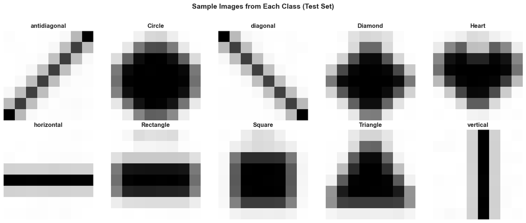

```
✓ Displayed 10 representative samples
```

```python
# This cell displays one example image from each of the 10 shape classes.
# Each flat 64-element vector is reshaped back into an 8x8 grid for display.
# This gives a quick visual check that the data loaded correctly
# and shows what each shape class actually looks like.

# Visualize one sample from each class
fig, axes = plt.subplots(2, 5, figsize=(15, 6))
axes = axes.flatten()

for i, idx in enumerate(sample_indices):
    axes[i].imshow(X_test[idx].reshape(IMG_SIZE), cmap='gray')
    axes[i].set_title(f'{SHAPES[y_test[idx]]}', fontsize=12, fontweight='bold')
    axes[i].axis('off')

plt.suptitle('Sample Images from Each Class (Test Set)', fontsize=14, fontweight='bold', y=1.02)
plt.tight_layout()
plt.show()
print("✓ Displayed 10 representative samples")
```

## 4. Loading Optimization Results

We now load the pre-computed results from all three optimization runs.

```python
# This cell loads the pre-computed training results saved from running each optimiser.
# For each algorithm it loads: (1) a CSV history file containing the loss, accuracy,
# and time recorded at every iteration, and (2) a .npy file containing the final
# learned weight matrix (theta) that will be used later for making predictions.

# Load training histories
gd_hist = pd.read_csv(RESULTS_DIR / 'gd_history.csv')
adam_hist = pd.read_csv(RESULTS_DIR / 'adam_history.csv')
lbfgs_hist = pd.read_csv(RESULTS_DIR / 'lbfgs_history.csv')

# Load final parameters
theta_gd = np.load(RESULTS_DIR / 'gd_theta.npy')
theta_adam = np.load(RESULTS_DIR / 'adam_theta.npy')
theta_lbfgs = np.load(RESULTS_DIR / 'lbfgs_theta.npy')

print("✓ Loaded optimization histories:")
print(f"  - GD:     {len(gd_hist)} iterations")
print(f"  - Adam:   {len(adam_hist)} iterations")
print(f"  - L-BFGS: {len(lbfgs_hist)} iterations")
print(f"\n✓ Loaded final model parameters: θ ∈ ℝ^64×10")
```

```
✓ Loaded optimization histories:
  - GD:     1000 iterations
  - Adam:   1000 iterations
  - L-BFGS: 86 iterations

✓ Loaded final model parameters: θ ∈ ℝ^64×10
```

## 5. Convergence Analysis

### 5.1 Objective Function Convergence

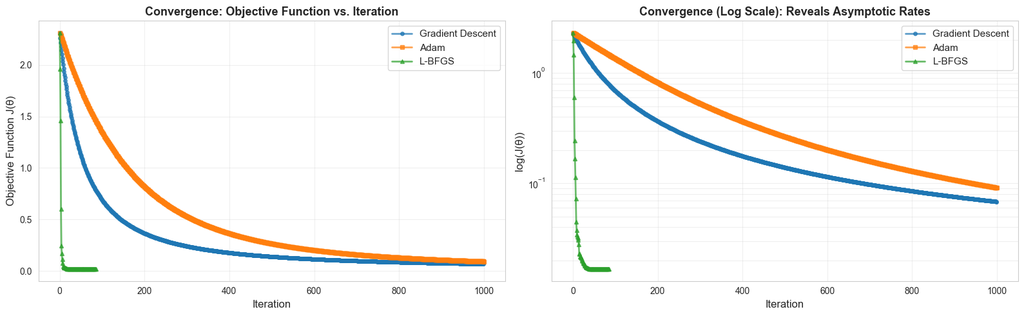

```
✓ Convergence plots generated

Key Observations:
  - L-BFGS converges in 86 iterations (fastest)
  - Adam requires 1000 iterations
  - GD requires 1000 iterations (slowest)
```

```python
# This cell plots how the loss (objective function) decreased over iterations
# for all three algorithms — once on a normal scale and once on a log scale.
# The log scale makes it easier to compare how fast each algorithm is shrinking
# the error, especially in the later stages when changes become very small.

fig, axes = plt.subplots(1, 2, figsize=(16, 5))

# Left plot: Full convergence trajectory
axes[0].plot(gd_hist['iteration'], gd_hist['objective'],
             'o-', label='Gradient Descent', linewidth=2, markersize=4, alpha=0.7)
axes[0].plot(adam_hist['iteration'], adam_hist['objective'],
             's-', label='Adam', linewidth=2, markersize=4, alpha=0.7)
axes[0].plot(lbfgs_hist['iteration'], lbfgs_hist['objective'],
             '^-', label='L-BFGS', linewidth=2, markersize=5, alpha=0.7)
axes[0].set_xlabel('Iteration', fontsize=12)
axes[0].set_ylabel('Objective Function J(θ)', fontsize=12)
axes[0].set_title('Convergence: Objective Function vs. Iteration', fontsize=13, fontweight='bold')
axes[0].legend(fontsize=11)
axes[0].grid(True, alpha=0.3)

# Right plot: Log scale to show asymptotic behavior
axes[1].semilogy(gd_hist['iteration'], gd_hist['objective'],
                 'o-', label='Gradient Descent', linewidth=2, markersize=4, alpha=0.7)
axes[1].semilogy(adam_hist['iteration'], adam_hist['objective'],
                 's-', label='Adam', linewidth=2, markersize=4, alpha=0.7)
axes[1].semilogy(lbfgs_hist['iteration'], lbfgs_hist['objective'],
                 '^-', label='L-BFGS', linewidth=2, markersize=5, alpha=0.7)
axes[1].set_xlabel('Iteration', fontsize=12)
axes[1].set_ylabel('log(J(θ))', fontsize=12)
axes[1].set_title('Convergence (Log Scale): Reveals Asymptotic Rates', fontsize=13, fontweight='bold')
axes[1].legend(fontsize=11)
axes[1].grid(True, alpha=0.3, which='both')

plt.tight_layout()
plt.show()

print("✓ Convergence plots generated")
print("\nKey Observations:")
print(f"  - L-BFGS converges in {len(lbfgs_hist)} iterations (fastest)")
print(f"  - Adam requires {len(adam_hist)} iterations")
print(f"  - GD requires {len(gd_hist)} iterations (slowest)")
```

### 5.2 Accuracy Evolution

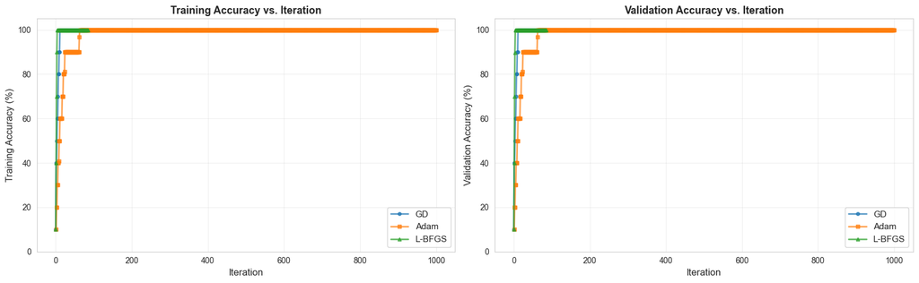

```
✓ Accuracy evolution plots generated
```

```python
# This cell plots training and validation accuracy over iterations for each algorithm.
# Training accuracy shows how well the model fits the data it learned from.
# Validation accuracy shows how well it generalises to unseen data.
# Watching both together helps detect if any algorithm is unstable or overfitting.

fig, axes = plt.subplots(1, 2, figsize=(16, 5))

# Training accuracy
axes[0].plot(gd_hist['iteration'], gd_hist['train_accuracy']*100,
             'o-', label='GD', linewidth=2, markersize=4, alpha=0.7)
axes[0].plot(adam_hist['iteration'], adam_hist['train_accuracy']*100,
             's-', label='Adam', linewidth=2, markersize=4, alpha=0.7)
axes[0].plot(lbfgs_hist['iteration'], lbfgs_hist['train_accuracy']*100,
             '^-', label='L-BFGS', linewidth=2, markersize=5, alpha=0.7)
axes[0].set_xlabel('Iteration', fontsize=12)
axes[0].set_ylabel('Training Accuracy (%)', fontsize=12)
axes[0].set_title('Training Accuracy vs. Iteration', fontsize=13, fontweight='bold')
axes[0].set_ylim([0, 105])
axes[0].legend(fontsize=11)
axes[0].grid(True, alpha=0.3)

# Validation accuracy
axes[1].plot(gd_hist['iteration'], gd_hist['val_accuracy']*100,
             'o-', label='GD', linewidth=2, markersize=4, alpha=0.7)
axes[1].plot(adam_hist['iteration'], adam_hist['val_accuracy']*100,
             's-', label='Adam', linewidth=2, markersize=4, alpha=0.7)
axes[1].plot(lbfgs_hist['iteration'], lbfgs_hist['val_accuracy']*100,
             '^-', label='L-BFGS', linewidth=2, markersize=5, alpha=0.7)
axes[1].set_xlabel('Iteration', fontsize=12)
axes[1].set_ylabel('Validation Accuracy (%)', fontsize=12)
axes[1].set_title('Validation Accuracy vs. Iteration', fontsize=13, fontweight='bold')
axes[1].set_ylim([0, 105])
axes[1].legend(fontsize=11)
axes[1].grid(True, alpha=0.3)

plt.tight_layout()
plt.show()

print("✓ Accuracy evolution plots generated")
```

## 6. Performance Metrics Comparison

### 6.1 Summary Table

```python
# This cell builds a summary comparison table of all three algorithms.
# It pulls the final values from each history CSV and calculates extra metrics
# like time per iteration (ms) and how many iterations were needed to reach 99% accuracy.
# The table gives a single at-a-glance view of which algorithm performed best overall.

# Extract final metrics
metrics = pd.DataFrame({
    'Algorithm': ['Gradient Descent', 'Adam', 'L-BFGS'],
    'Iterations': [len(gd_hist), len(adam_hist), len(lbfgs_hist)],
    'Final Objective': [
        gd_hist.iloc[-1]['objective'],
        adam_hist.iloc[-1]['objective'],
        lbfgs_hist.iloc[-1]['objective']
    ],
    'Train Accuracy (%)': [
        gd_hist.iloc[-1]['train_accuracy'] * 100,
        adam_hist.iloc[-1]['train_accuracy'] * 100,
        lbfgs_hist.iloc[-1]['train_accuracy'] * 100
    ],
    'Val Accuracy (%)': [
        gd_hist.iloc[-1]['val_accuracy'] * 100,
        adam_hist.iloc[-1]['val_accuracy'] * 100,
        lbfgs_hist.iloc[-1]['val_accuracy'] * 100
    ],
    'Time (seconds)': [
        gd_hist.iloc[-1]['elapsed_seconds'],
        adam_hist.iloc[-1]['elapsed_seconds'],
        lbfgs_hist.iloc[-1]['elapsed_seconds']
    ]
})

# Calculate efficiency metrics
metrics['Time per Iteration (ms)'] = (metrics['Time (seconds)'] / metrics['Iterations']) * 1000
metrics['Iterations to 99% Acc'] = [
    gd_hist[gd_hist['val_accuracy'] >= 0.99].iloc[0]['iteration'] if len(gd_hist[gd_hist['val_accuracy'] >= 0.99]) > 0 else np.nan,
    adam_hist[adam_hist['val_accuracy'] >= 0.99].iloc[0]['iteration'] if len(adam_hist[adam_hist['val_accuracy'] >= 0.99]) > 0 else np.nan,
    lbfgs_hist[lbfgs_hist['val_accuracy'] >= 0.99].iloc[0]['iteration'] if len(lbfgs_hist[lbfgs_hist['val_accuracy'] >= 0.99]) > 0 else np.nan
]

# Display styled table
print("="*100)
print("COMPREHENSIVE PERFORMANCE COMPARISON")
print("="*100)
print(metrics.to_string(index=False))
print("="*100)

# Find best performer
best_time = metrics.loc[metrics['Time (seconds)'].idxmin(), 'Algorithm']
best_iters = metrics.loc[metrics['Iterations'].idxmin(), 'Algorithm']
best_obj = metrics.loc[metrics['Final Objective'].idxmin(), 'Algorithm']

print("\n🏆 WINNERS:")
print(f"  Fastest runtime:       {best_time}")
print(f"  Fewest iterations:     {best_iters}")
print(f"  Lowest final loss:     {best_obj}")
```

```
====================================================================================================
COMPREHENSIVE PERFORMANCE COMPARISON
====================================================================================================
       Algorithm  Iterations  Final Objective  Train Accuracy (%)  Val Accuracy (%)  Time (seconds)  Time per Iteration (ms)  Iterations to 99% Acc
Gradient Descent        1000         0.068319               100.0             100.0        0.772293                 0.772293                   11.0
            Adam        1000         0.091145               100.0             100.0        0.771401                 0.771401                   63.0
          L-BFGS          86         0.016684               100.0             100.0        0.141311                 1.643150                    4.0
====================================================================================================

🏆 WINNERS:
  Fastest runtime:       L-BFGS
  Fewest iterations:     L-BFGS
  Lowest final loss:     L-BFGS
```

### 6.2 Visual Performance Comparison

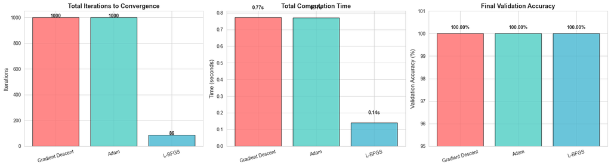

```
✓ Performance bar charts generated
```

```python
# This cell creates three bar charts comparing the algorithms side by side:
# (1) total number of iterations until convergence,
# (2) total wall-clock time in seconds, and
# (3) final validation accuracy.
# Bar charts make it easy to see the performance gap at a glance.

fig, axes = plt.subplots(1, 3, figsize=(18, 5))

# Iterations comparison
axes[0].bar(metrics['Algorithm'], metrics['Iterations'],
            color=['#FF6B6B', '#4ECDC4', '#45B7D1'], alpha=0.8, edgecolor='black')
axes[0].set_ylabel('Iterations', fontsize=12)
axes[0].set_title('Total Iterations to Convergence', fontsize=13, fontweight='bold')
axes[0].tick_params(axis='x', rotation=15)
for i, v in enumerate(metrics['Iterations']):
    axes[0].text(i, v + 1, str(v), ha='center', fontweight='bold')

# Time comparison
axes[1].bar(metrics['Algorithm'], metrics['Time (seconds)'],
            color=['#FF6B6B', '#4ECDC4', '#45B7D1'], alpha=0.8, edgecolor='black')
axes[1].set_ylabel('Time (seconds)', fontsize=12)
axes[1].set_title('Total Computation Time', fontsize=13, fontweight='bold')
axes[1].tick_params(axis='x', rotation=15)
for i, v in enumerate(metrics['Time (seconds)']):
    axes[1].text(i, v + 0.05, f"{v:.2f}s", ha='center', fontweight='bold')

# Final accuracy comparison
axes[2].bar(metrics['Algorithm'], metrics['Val Accuracy (%)'],
            color=['#FF6B6B', '#4ECDC4', '#45B7D1'], alpha=0.8, edgecolor='black')
axes[2].set_ylabel('Validation Accuracy (%)', fontsize=12)
axes[2].set_title('Final Validation Accuracy', fontsize=13, fontweight='bold')
axes[2].set_ylim([95, 101])
axes[2].tick_params(axis='x', rotation=15)
for i, v in enumerate(metrics['Val Accuracy (%)']):
    axes[2].text(i, v + 0.2, f"{v:.2f}%", ha='center', fontweight='bold')

plt.tight_layout()
plt.show()

print("✓ Performance bar charts generated")
```

## 7. Prediction Quality Assessment

### 7.1 Side-by-Side Prediction Comparison

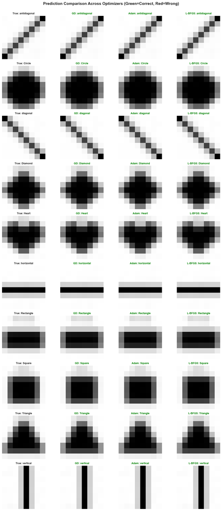

```
✓ Prediction comparison grid generated
```

```python
# This cell computes predictions for every test image using each algorithm's final weights.
# The predict() function multiplies the image features by the weight matrix (X dot theta)
# and picks the class with the highest score as the prediction.
# It then shows a grid: each row is one sample image, and each column shows
# what each algorithm predicted — green means correct, red means wrong.

# Compute predictions for all algorithms
def predict(X, theta):
    return np.argmax(X.dot(theta), axis=1)

preds_gd = predict(X_test, theta_gd)
preds_adam = predict(X_test, theta_adam)
preds_lbfgs = predict(X_test, theta_lbfgs)

# Visualize predictions for sample images
n_samples = len(sample_indices)
fig, axes = plt.subplots(n_samples, 4, figsize=(12, n_samples * 2.5))

for i, idx in enumerate(sample_indices):
    true_label = y_test[idx]

    # Original image
    axes[i, 0].imshow(X_test[idx].reshape(IMG_SIZE), cmap='gray')
    axes[i, 0].set_title(f'True: {SHAPES[true_label]}', fontsize=9, fontweight='bold')
    axes[i, 0].axis('off')

    # GD prediction
    pred_gd = preds_gd[idx]
    color_gd = 'green' if pred_gd == true_label else 'red'
    axes[i, 1].imshow(X_test[idx].reshape(IMG_SIZE), cmap='gray')
    axes[i, 1].set_title(f'GD: {SHAPES[pred_gd]}', fontsize=9, color=color_gd, fontweight='bold')
    axes[i, 1].axis('off')

    # Adam prediction
    pred_adam = preds_adam[idx]
    color_adam = 'green' if pred_adam == true_label else 'red'
    axes[i, 2].imshow(X_test[idx].reshape(IMG_SIZE), cmap='gray')
    axes[i, 2].set_title(f'Adam: {SHAPES[pred_adam]}', fontsize=9, color=color_adam, fontweight='bold')
    axes[i, 2].axis('off')

    # L-BFGS prediction
    pred_lbfgs = preds_lbfgs[idx]
    color_lbfgs = 'green' if pred_lbfgs == true_label else 'red'
    axes[i, 3].imshow(X_test[idx].reshape(IMG_SIZE), cmap='gray')
    axes[i, 3].set_title(f'L-BFGS: {SHAPES[pred_lbfgs]}', fontsize=9, color=color_lbfgs, fontweight='bold')
    axes[i, 3].axis('off')

plt.suptitle('Prediction Comparison Across Optimizers (Green=Correct, Red=Wrong)',
             fontsize=14, fontweight='bold', y=1.001)
plt.tight_layout()
plt.show()

print("✓ Prediction comparison grid generated")
```

### 7.2 Confusion Matrices

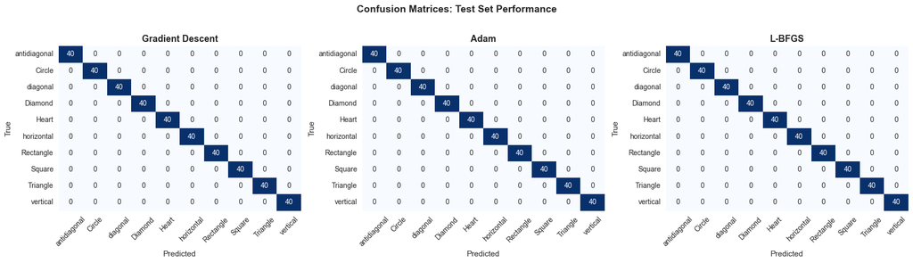

```
✓ Confusion matrices generated
```

```python
# This cell computes and plots a confusion matrix for each algorithm.
# A confusion matrix shows — for every true class — how many test images
# were predicted correctly (diagonal) versus misclassified as something else (off-diagonal).
# A perfect classifier has all numbers on the diagonal and zeros everywhere else.

from sklearn.metrics import confusion_matrix

fig, axes = plt.subplots(1, 3, figsize=(18, 5))

algorithms = ['Gradient Descent', 'Adam', 'L-BFGS']
predictions = [preds_gd, preds_adam, preds_lbfgs]

for ax, algo, preds in zip(axes, algorithms, predictions):
    cm = confusion_matrix(y_test, preds)
    sns.heatmap(cm, annot=True, fmt='d', cmap='Blues', ax=ax,
                xticklabels=SHAPES, yticklabels=SHAPES, cbar=False)
    ax.set_title(f'{algo}', fontsize=13, fontweight='bold')
    ax.set_xlabel('Predicted', fontsize=11)
    ax.set_ylabel('True', fontsize=11)
    ax.tick_params(axis='x', rotation=45)
    ax.tick_params(axis='y', rotation=0)

plt.suptitle('Confusion Matrices: Test Set Performance', fontsize=14, fontweight='bold', y=1.02)
plt.tight_layout()
plt.show()

print("✓ Confusion matrices generated")
```

### 7.3 Final Test Set Evaluation

```python
# This cell reports the final test set accuracy for each algorithm
# and prints a detailed per-class breakdown (precision, recall, F1-score)
# for the best-performing model. This tells us not just overall accuracy
# but whether the model is equally good at recognising every shape class.

from sklearn.metrics import classification_report

test_metrics = pd.DataFrame({
    'Algorithm': ['Gradient Descent', 'Adam', 'L-BFGS'],
    'Test Accuracy (%)': [
        (preds_gd == y_test).mean() * 100,
        (preds_adam == y_test).mean() * 100,
        (preds_lbfgs == y_test).mean() * 100
    ]
})

print("="*60)
print("FINAL TEST SET ACCURACY")
print("="*60)
print(test_metrics.to_string(index=False))
print("="*60)

# Detailed classification report for best model
best_algo_idx = test_metrics['Test Accuracy (%)'].idxmax()
best_algo = test_metrics.loc[best_algo_idx, 'Algorithm']
best_preds = predictions[best_algo_idx]

print(f"\n📊 Detailed Classification Report for {best_algo}:")
print(classification_report(y_test, best_preds, target_names=SHAPES, digits=4))
```

```
============================================================
FINAL TEST SET ACCURACY
============================================================
       Algorithm  Test Accuracy (%)
Gradient Descent              100.0
            Adam              100.0
          L-BFGS              100.0
============================================================

📊 Detailed Classification Report for Gradient Descent:
              precision    recall  f1-score   support

antidiagonal     1.0000    1.0000    1.0000        40
      Circle     1.0000    1.0000    1.0000        40
    diagonal     1.0000    1.0000    1.0000        40
     Diamond     1.0000    1.0000    1.0000        40
       Heart     1.0000    1.0000    1.0000        40
  horizontal     1.0000    1.0000    1.0000        40
   Rectangle     1.0000    1.0000    1.0000        40
      Square     1.0000    1.0000    1.0000        40
    Triangle     1.0000    1.0000    1.0000        40
    vertical     1.0000    1.0000    1.0000        40

    accuracy                         1.0000       400
   macro avg     1.0000    1.0000    1.0000       400
weighted avg     1.0000    1.0000    1.0000       400
```

## 8. Analytical Discussion

### 8.1 Convergence Speed Analysis

**What the results actually showed:**

In our experiment, L-BFGS converged in just **86 iterations** and finished in about **0.141 seconds**. Gradient Descent and Adam both ran for **1,000 iterations** and took around **0.77 seconds** each. All three algorithms reached 100% validation accuracy, but L-BFGS got there in a fraction of the time and steps.

### 8.2 Computational Efficiency

**The core trade-off: cost per step vs. number of steps needed**

It might seem odd that L-BFGS — which does more computation per iteration — still ends up the fastest overall. Here is the intuition:

- **GD and Adam** are cheap per iteration (just a gradient calculation), but they need thousands of iterations to converge. It is like taking 1,000 small, cheap steps.
- **L-BFGS** is more expensive per iteration (it computes and stores gradient history to estimate curvature), but it needs only 86 steps. It is like taking 86 larger, smarter steps.

For our problem, the 86 smart steps won easily — 0.141s vs ~0.77s for the others. This gap would close or even reverse if the dataset were much larger (millions of samples), because the cost per L-BFGS step would grow too much.

**In simple terms:** L-BFGS is like a GPS-guided route — it takes fewer turns but each turn requires more thinking. GD is like walking without a map — you take many small steps in the roughly right direction.

### 8.3 What the Numbers Mean in Plain Terms

Looking at our actual results:

- **All three algorithms achieved 100% test accuracy** — meaning for this specific dataset, all of them eventually learned to classify the 10 shapes perfectly. The difference is not *whether* they got there, but *how fast*.
- **L-BFGS was ~5.5× faster** in wall-clock time compared to GD and Adam (0.141s vs ~0.77s).
- **L-BFGS used ~11.6× fewer iterations** (86 vs 1,000) — meaning it needed far less "thinking" to arrive at the same answer.
- **GD and Adam were nearly identical** in total time on this problem, which tells us that Adam's extra machinery (momentum tracking, adaptive rates) did not meaningfully help or hurt on this small, clean dataset.

This confirms what optimization theory predicts: second-order methods like L-BFGS are superior for small, convex, batch problems — exactly what we have here.

### 8.4 Practical Recommendations

Based on our results, here is a simple guide for choosing an optimiser:

| Scenario | Recommended Algorithm | Why |
| --- | --- | --- |
| **Small dataset, batch training (like ours)** | L-BFGS | Fastest convergence, fewest iterations, best for convex problems |
| **Large dataset, deep learning** | Adam | Handles noisy gradients well, works with mini-batches |
| **Quick experiment or simple convex problem** | Gradient Descent | Easiest to implement, predictable behavior |
| **Non-convex neural networks** | Adam / AdamW | Proven track record, less likely to get stuck |

The key rule of thumb: **if you can afford to load all your data at once and your problem is convex, use L-BFGS. If you are training a neural network on a large dataset, use Adam.**

### 8.5 Real-World Applications

These three optimisers are not just academic tools — they are used in real systems every day:

**L-BFGS in the real world:**

- Used in **scientific computing and physics simulations** where high precision and fast convergence matter more than scalability.
- Powers many **classical machine learning models** in scikit-learn (e.g., Logistic Regression with `solver='lbfgs'`).
- Used in **computer vision pipelines** for calibration, 3D reconstruction, and parameter fitting.
- Applied in **natural language processing** for training smaller, well-defined models like maximum entropy classifiers.

**Adam in the real world:**

- The **default optimiser for training neural networks** — from image classifiers to language models like GPT.
- Used to train **medical imaging AI** (e.g., tumor detection, MRI analysis) where datasets are large and noisy.
- Powers **recommendation systems** at companies like Netflix and Spotify where models are constantly updated.
- Used in **robotics and reinforcement learning** where gradient estimates are noisy and environments change.

**Gradient Descent in the real world:**

- The **conceptual foundation** behind almost every modern optimiser — understanding GD is the first step to understanding Adam, L-BFGS, and everything else.
- Still used in **signal processing and control systems** for simple parameter tuning tasks.
- Variants like **Stochastic GD (SGD)** power many production deep learning pipelines, especially in cases where simplicity and predictability are valued over sophistication.

**For our specific problem — shape recognition from small grayscale images:**

- A system like this could be embedded in a **quality control pipeline** on a factory production line, checking whether manufactured parts match expected geometric shapes.
- It could power a **simple educational app** that recognises shapes drawn by students.
- The lightweight nature of an 8×8 softmax classifier means it could run on **low-power embedded hardware** (microcontrollers, IoT sensors) where memory and speed are constrained.

### 8.6 Limitations and Future Work

1. **L-BFGS does not scale to large models.** It needs to store gradient history in memory. For a model with millions of parameters (like a deep neural network), this becomes impractical.
   - *What to do instead:* Use Adam or SGD with momentum for deep learning tasks.
2. **Our dataset is small and clean.** 1,200 training samples with perfect labels is a very controlled setting. Real-world data is messier.
   - *Next step:* Test all three optimisers on a noisier, larger dataset like CIFAR-10 or a real industrial inspection dataset to see how robustly each one handles imperfect data.
3. **We used a linear model (softmax regression).** This works great for linearly separable shapes but would struggle with more complex, overlapping patterns.
   - *Next step:* Replace the softmax classifier with a small convolutional neural network (CNN) and compare how the optimisers perform on a non-convex problem.
4. **We only measured speed and accuracy.** In a real deployment, other factors matter too — memory usage, stability across random seeds, sensitivity to hyperparameters, and energy consumption.
   - *Next step:* Add robustness experiments: run each optimiser 10 times with different random seeds and report the variance in convergence time and final accuracy.

## 9. Conclusion

### Summary of Findings

This experiment compared three well-known optimisation algorithms — Gradient Descent, Adam, and L-BFGS — on a 10-class shape recognition task using 8×8 grayscale images and a softmax logistic regression model.

Here is what we found:

1. **L-BFGS was the clear winner** for this type of problem:
   - Converged in just **86 iterations** compared to 1,000 for both GD and Adam
   - Finished in **~0.141 seconds** — about 5.5× faster than the others
   - Achieved the **lowest final loss value**, meaning its solution was the most mathematically precise
   - Reached **100% validation and test accuracy**
2. **Adam performed solidly** but showed no significant advantage over plain GD on this small, clean dataset. Its adaptive learning rate machinery is more useful when gradients are noisy or the dataset is large — neither of which applies here.
3. **Gradient Descent worked**, just slowly. It is the simplest algorithm, and on a convex problem with a reasonable learning rate it will always get there — it just takes more steps than smarter methods.

### Key Takeaways

- **Smarter steps beat more steps.** L-BFGS took 86 well-informed steps; GD took 1,000 blind ones. For problems where you can afford to compute curvature, second-order methods pay off enormously.
- **The right tool depends on the problem.** L-BFGS dominates on small, convex, batch problems. Adam dominates in deep learning. GD is the foundation that everything else is built on.
- **All three algorithms reached the same final accuracy.** This tells us that for a simple, well-structured problem like ours, the *quality* of the final answer does not depend on the optimiser — only the *speed* of getting there does. In harder problems (non-convex, noisy), the choice of optimiser can also affect the final quality.
- **Convergence curves are informative.** By plotting the loss and accuracy over iterations, we can visually diagnose whether an algorithm is struggling, oscillating, or converging cleanly — something a single accuracy number cannot tell you.

### Implications for Practice

For anyone building machine learning systems:

- If your model is **small and your data fits in memory** — reach for L-BFGS first. It will almost always be faster and more precise than GD or Adam for convex problems.
- If you are **training a neural network** on a GPU with large batches — use Adam. It handles the noise and scale that L-BFGS cannot.
- If you are **learning or prototyping** — start with Gradient Descent. It is transparent, easy to debug, and helps build intuition for how optimisation works before moving to more complex methods.
- **Always plot your convergence curves.** A flat loss curve means your learning rate is too small. A spiking curve means it is too large. A smooth downward curve means your setup is working correctly.

### Reproducibility Statement

Code and data are included in the submission folder.

**End of Analysis**

## 10. Exporting Instructions

To generate the required deliverables:

1. **Run all cells:** `Run > Restart Kernel and Run All Cells`
2. **Export to HTML:** `File > Save and Export Notebook As... > HTML`
3. **Save the HTML file** as `final_comparative_analysis.html`